jlehavi.github.io

# **Final Tutorial: Making Smarter Bets**

Jack Lehavi and Jonah Boyer

Link to GitHub: https://Jlehavi.github.io

## **Introduction**

In our project, we aimed to find a solution to the growing problem of unsuccessful NFL betting. NFL fans that wish to place bets on weekly games face challenges as many people choose to bet based on their emotions, which leads to **biased**, **unfavorable**, and **inconsistent** **results**.

Additionally, we found that “Bettors who rely on emotions often experience lower success rates compared to those who employ analytical approaches. A survey of 1,000 UK sports bettors revealed that 59.48% relied on gut instinct, with 32% regretting such decisions. In contrast, 64.67% acknowledged that research-driven bets yield better outcomes.” – The Sun UK

## **Key Questions**

1. Is there a relationship between Elo predicted spread and historical market spreads, and if so, can this relationship be used as a predictor of NFL games?
2. What combination/weight of Elo ratings, historical NFL results, market data, weather, and type of stadium most accurately predicts which team “covers the spread” in each NFL game?

## **Housekeeping / Data Loading**

The first step of the exercize is to load in all libraries and data sources that will be used throughout the tutorial. We have four data sources: nfl_elo, nfl_stadiums, nfl_teams, and spreadspoke scores. We will explain the details of each data set as we progress though the tutorial.

```python
import pandas as pd
import matplotlib.pyplot as plt
import numpy as np
from datetime import timedelta
from google.colab import drive
from sklearn.preprocessing import StandardScaler
from sklearn.linear_model import LogisticRegression
from sklearn.model_selection import TimeSeriesSplit, cross_val_score
from sklearn.metrics import accuracy_score, classification_report, confusion_matrix, roc_auc_score
drive.mount('/content/drive')
```

```python
file_path2 = '/content/drive/MyDrive/ELO Data/nfl_elo.csv'
file_path3 = '/content/drive/MyDrive/ELO Data/nfl_stadiums.csv'
file_path4 = '/content/drive/MyDrive/ELO Data/nfl_teams.csv'
file_path5 = '/content/drive/MyDrive/ELO Data/spreadspoke_scores.csv'

df_elo_total = pd.read_csv(file_path2)
df_stadiums = pd.read_csv(file_path3, encoding="unicode_escape")
df_teams = pd.read_csv(file_path4)
df_scores = pd.read_csv(file_path5)
```

## **Examining Data Set 1: NFL Elo Ratings**

The NFL Elo ratings dataset was created by fivethirtyeight.com and assigns a power rating (around 1500 is average) for each team that help determine win probability for a given matchup. The prediction takes into account quality of teams, location of game played, strength of quarterback, and more. In the dataset, there are variables showing each team, the date the game was played, the Elo ratings for each team before and after the game, the home away designations, and whether the game was in the playoffs (and more).

### **Pre-processing steps**

These changes made it much easier to distinguish the home and away team, a key point in our model as the model aims to predict the "whether the home team covers the spread".

```python
# rename columns to make more clear

df_elo_total.rename(columns={
    'team1': 'home_team', 'team2': 'away_team',
    'elo1_pre': 'home_elo_pre', 'elo2_pre': 'away_elo_pre',
    'elo_prob1': 'home_elo_prob', 'elo_prob2': 'away_elo_prob',
    'elo1_post': 'home_elo_post', 'elo2_post': 'away_elo_post',
    'qbelo1_pre': 'home_qbelo_pre', 'qbelo2_pre': 'away_qbelo_pre',
    'qb1': 'home_qb', 'qb2': 'away_qb',
    'qb1_value_pre': 'home_qb_value_pre', 'qb2_value_pre': 'away_qb_value_pre',
    'qb1_adj': 'home_qb_adj', 'qb2_adj': 'away_qb_adj',
    'qbelo_prob1': 'home_qbelo_prob', 'qbelo_prob2': 'away_qbelo_prob',
    'qb1_game_value': 'home_qb_game_value', 'qb2_game_value': 'away_qb_game_value',
    'qb1_value_post': 'home_qb_value_post', 'qb2_value_post': 'away_qb_value_post',
    'qbelo1_post': 'home_qbelo_post', 'qbelo2_post': 'away_qbelo_post',
    'score1': 'home_score', 'score2': 'away_score'}, inplace=True)
```

**Convert Playoff Column:** change the playoff column from a categorical variable to quantitative value to enable easier processing for the modeling.

```python
# change playoff from categorical to quantitative
df_elo_total['playoff'].fillna(0, inplace=True)
df_elo_total['playoff'] = df_elo_total['playoff'].apply(lambda x: 1 if x == 'w' else (2 if x == 'd' else (3 if x == 'c' else (4 if x == 's' else 0))))
```

**Add Elo Difference (elo_diff) Column:** this new column was created to measure the difference in Elo ratings after each game. Additionally, several adjustments were made (in accordance with 538's guidelines) to help better indicate the relative strength of each opponent.

Adjustments: home team recieves 48 point home field advantage & and Elo is scaled 20% for playoff games.

```python
# add elo diff columns
df_elo_total['elo_diff'] = df_elo_total['home_elo_post'] - df_elo_total['away_elo_post']
df_elo_total['elo_diff'] += df_elo_total['neutral'].apply(lambda x: 0 if x == 1 else 48) # home field advantage adjustment
df_elo_total['elo_diff'] = df_elo_total.apply( # playoff adjustment
    lambda row: row['elo_diff'] * 1.2 if row['playoff'] != 0 else row['elo_diff'],
    axis=1
)
```

**Calculate Elo-derived Betting Spread:** we divided the Elo difference by 25 to find the predicted betting spread. This metric is very important in the development of the model because it provides a basis for comparison between the historical spreads set by the betting markets, and the elo predicted lines. These discrepencies give us insight on the accuracy of each spread, which helps inform the model to make better betting decisions.

```python
df_elo_total['betting_spread'] = df_elo_total['elo_diff'] / 25 # betting spread -- positive value indicate home team favored, negative means away is favored
```

**Filter Dates and Clone Dataframe:** Finally, we filtered data before 1978 and created a cleaned version of the dataframe.

```python
# only display dates after 1978 to match with other dataset
df_elo_total = df_elo_total[df_elo_total['date'] >= '1978-01-01']

# Display the cleaned structure and a few rows to the user
df_elo_total_cleaned = df_elo_total.copy()
df_elo_total_cleaned
```

|  | date | season | neutral | playoff | home_team | away_team | home_elo_pre | away_elo_pre | home_elo_prob | away_elo_prob | ... | away_qb_value_post | home_qbelo_post | away_qbelo_post | home_score | away_score | quality | importance | total_rating | elo_diff | betting_spread |
| --- | --- | --- | --- | --- | --- | --- | --- | --- | --- | --- | --- | --- | --- | --- | --- | --- | --- | --- | --- | --- | --- |
| 6086 | 1978-01-01 | 1977 | 0 | 3 | DAL | MIN | 1706.986000 | 1628.789000 | 0.695150 | 0.304850 | ... | 44.893726 | 1708.911137 | 1634.213096 | 23 | 6 | 97.0 | NaN | NaN | 191.146800 | 7.645872 |
| 6087 | 1978-01-01 | 1977 | 0 | 3 | DEN | OAK | 1715.594000 | 1717.749000 | 0.589468 | 0.410532 | ... | 103.277414 | 1717.354256 | 1705.926822 | 20 | 17 | 100.0 | NaN | NaN | 81.573600 | 3.262944 |
| 6088 | 1978-01-15 | 1977 | 1 | 4 | DEN | DAL | 1726.660000 | 1723.532000 | 0.504501 | 0.495499 | ... | 145.605083 | 1686.607565 | 1739.657828 | 10 | 27 | 100.0 | NaN | NaN | -66.338400 | -2.653536 |
| 6089 | 1978-09-02 | 1978 | 0 | 0 | TB | NYG | 1343.269000 | 1436.601000 | 0.459317 | 0.540683 | ... | -12.208069 | 1321.007371 | 1453.457653 | 13 | 19 | 4.0 | NaN | NaN | -80.630000 | -3.225200 |
| 6090 | 1978-09-03 | 1978 | 0 | 0 | BUF | PIT | 1382.708000 | 1582.923000 | 0.314673 | 0.685327 | ... | 106.394378 | 1373.031143 | 1596.883528 | 17 | 28 | 38.0 | NaN | NaN | -181.681000 | -7.267240 |
| ... | ... | ... | ... | ... | ... | ... | ... | ... | ... | ... | ... | ... | ... | ... | ... | ... | ... | ... | ... | ... | ... |
| 17090 | 2022-01-23 | 2021 | 0 | 2 | TB | LAR | 1681.797158 | 1632.341105 | 0.659005 | 0.340995 | ... | 199.786107 | 1629.446888 | 1635.265484 | 27 | 30 | 96.0 | 100.0 | 98.0 | 70.689084 | 2.827563 |
| 17091 | 2022-01-23 | 2021 | 0 | 2 | KC | BUF | 1699.470145 | 1683.332367 | 0.614689 | 0.385311 | ... | 291.477231 | 1700.324756 | 1644.036577 | 42 | 36 | 100.0 | 100.0 | 100.0 | 111.674672 | 4.466987 |
| 17092 | 2022-01-30 | 2021 | 0 | 3 | KC | CIN | 1713.932369 | 1569.498961 | 0.769519 | 0.230481 | ... | 186.971396 | 1674.943733 | 1585.098917 | 24 | 27 | 98.0 | 100.0 | 99.0 | 174.327203 | 6.973088 |
| 17093 | 2022-01-30 | 2021 | 0 | 3 | LAR | SF | 1651.615346 | 1621.465562 | 0.633608 | 0.366392 | ... | 125.373817 | 1644.929010 | 1621.968494 | 20 | 17 | 96.0 | 100.0 | 98.0 | 117.149513 | 4.685981 |
| 17094 | 2022-02-13 | 2021 | 1 | 4 | CIN | LAR | 1593.079331 | 1661.352751 | 0.317089 | 0.682911 | ... | 200.283690 | 1576.868287 | 1653.159640 | 20 | 23 | 95.0 | 100.0 | 98.0 | -101.822672 | -4.072907 |

11009 rows × 35 columns

## **Examining Data Set 2: NFL Stadiums**

The nfl stadiums dataset contains data on ~120 stadiums, 30 of which are nfl stadiums. It has useful weather data on these stadiums such as the typical temperature as well as if stadiums are indoor, outdoor, or retractable, as well as grass type. These are interesting metrics to look at and see how much these factors might affect game outcomes or points scored

### **Pre-processing Steps**

```python
nfl_stadiums = [
    "Allegiant Stadium", "Arrowhead Stadium", "AT&T Stadium",
    "Bank of America Stadium", "Caesars Superdome", "Empower Field at Mile High",
    "FedEx Field", "FirstEnergy Stadium", "Ford Field",
    "GEHA Field at Arrowhead Stadium", "Gillette Stadium", "Hard Rock Stadium",
    "Highmark Stadium", "Lambeau Field", "Levi's Stadium",
    "Lincoln Financial Field", "Lucas Oil Stadium", "Lumen Field",
    "M&T Bank Stadium", "Mercedes-Benz Stadium", "MetLife Stadium",
    "Nissan Stadium", "NRG Stadium", "Paycor Stadium",
    "Raymond James Stadium", "SoFi Stadium", "Soldier Field",
    "State Farm Stadium", "TIAA Bank Field", "U.S. Bank Stadium"
]

df_stadiums.drop(columns=['stadium_location', 'stadium_address', 'stadium_weather_station_zipcode', 'stadium_capacity', 'stadium_weather_station', 'stadium_weather_station_name', 'stadium_latitude', 'stadium_longitude', 'stadium_azimuthangle', 'stadium_close', 'stadium_elevation'], inplace=True)
df_stadiums = df_stadiums[df_stadiums['stadium_name'].isin(nfl_stadiums)].copy()

df_stadiums
```

|  | stadium_name | stadium_open | stadium_type | stadium_weather_type | stadium_surface |
| --- | --- | --- | --- | --- | --- |
| 2 | Allegiant Stadium | 2020.0 | indoor | indoor | Grass |
| 7 | Arrowhead Stadium | 1972.0 | outdoor | cold | Grass |
| 8 | AT&T Stadium | 2009.0 | retractable | indoor | FieldTurf |
| 11 | Bank of America Stadium | 1996.0 | outdoor | moderate | Grass |
| 14 | Caesars Superdome | 1975.0 | indoor | indoor | FieldTurf |
| 24 | Empower Field at Mile High | 2001.0 | outdoor | cold | Grass |
| 27 | FedEx Field | 1997.0 | outdoor | moderate | Grass |
| 29 | FirstEnergy Stadium | 1999.0 | outdoor | cold | Grass |
| 30 | Ford Field | 2002.0 | indoor | indoor | FieldTurf |
| 34 | GEHA Field at Arrowhead Stadium | 1972.0 | outdoor | cold | Grass |
| 37 | Gillette Stadium | 2002.0 | outdoor | cold | FieldTurf |
| 38 | Hard Rock Stadium | 1987.0 | outdoor | warm | Grass |
| 41 | Highmark Stadium | 1973.0 | outdoor | cold | FieldTurf |
| 50 | Lambeau Field | 1957.0 | outdoor | cold | Grass |
| 52 | Levi's Stadium | 2014.0 | outdoor | moderate | Grass |
| 54 | Lincoln Financial Field | 2003.0 | outdoor | cold | Grass |
| 58 | Lucas Oil Stadium | 2008.0 | retractable | indoor | FieldTurf |
| 59 | Lumen Field | 2002.0 | outdoor | moderate | FieldTurf |
| 60 | M&T Bank Stadium | 1998.0 | outdoor | moderate | FieldTurf |
| 65 | Mercedes-Benz Stadium | 2017.0 | retractable | indoor | FieldTurf |
| 67 | MetLife Stadium | 2010.0 | outdoor | cold | FieldTurf |
| 72 | Nissan Stadium | 1999.0 | outdoor | moderate | Grass |
| 73 | NRG Stadium | 2002.0 | retractable | indoor | Grass |
| 77 | Paycor Stadium | 2000.0 | outdoor | cold | FieldTurf |
| 83 | Raymond James Stadium | 1998.0 | outdoor | warm | Grass |
| 92 | SoFi Stadium | 2020.0 | outdoor | warm | Hellas Matrix Turf |
| 93 | Soldier Field | 1926.0 | outdoor | cold | Grass |
| 96 | State Farm Stadium | 2006.0 | retractable | indoor | Grass |
| 104 | TIAA Bank Field | 1995.0 | outdoor | warm | Grass |
| 111 | U.S. Bank Stadium | 2016.0 | indoor | indoor | FieldTurf |

## **Examining Data Set 3: NFL Teams**

This dataset does not contain data with relavent predicting power, but it contains a mapping from nfl team names to their abbreviations, which is useful in merging our datasets on the same team_name index

## **Examining Data Set 4: Spreadspoke Scores**

This dataset contains data results from NFL games dating back to 1966 as well as betting odds dating back to 1979. The dataset draws information not only from the results of each NFL game, but meaningful statistics, predictions, weather factors, and stadium data that help tell a complete story on each result. Additionally, the data helps paint a picture on successful betting strategies employed historically, which could be helpful in building a more successful predictive betting model for NFL games.

### **Pre-processing Steps**

Drop Unnecessary Columns: drop columns such as weather humidity, weather detail, and many unnamed columns.

Remove Rows with Missing Key Data: remove rows with NaN values in the home score & over under columns. This is important because there columns are essential for analysis and if there were rows with missing data, it would compromise the conclusions.

```python
df_scores.drop(columns=['weather_humidity', 'weather_detail', 'Unnamed: 17', 'Unnamed: 18', 'Unnamed: 19', 'Unnamed: 20', 'Unnamed: 21', 'Unnamed: 22', 'Unnamed: 22', 'Unnamed: 23', 'Unnamed: 24', 'Unnamed: 25'], inplace=True)
df_scores.dropna(subset=['score_home', 'over_under_line'], inplace=True)
```

## **Merging Datasets Together**

This step synthesizes data from each data set and creates a cohesive dataframe (df_total) that will aid in completed useful EDA. This new dataframe contains game-level information (scores, teams, dates), stadium details, ELo-based metrics, and team names/abbreviations.

**Merge Stadium Info into Game Data:** merging the scores and stadiums data set on "stadium" using a left join to create df_games_stadiums

Additionally, rename several columns for clarity, map team names to abbreviations, and normalaize the date format.

```python
df_stadiums.rename(columns={'stadium_name': 'stadium'}, inplace=True)

df_games_stadiums = pd.merge(df_scores, df_stadiums, on='stadium', how='left') # merge stadium info into game data

df_games_stadiums['schedule_date'] = pd.to_datetime(df_games_stadiums['schedule_date']) # make date in normal date format

df_games_stadiums.rename(columns={'schedule_date': 'date', 'schedule_season': 'season', 'team_home': 'home_team', 'score_home': 'home_score', 'team_away': 'away_team', 'score_away': 'away_score'}, inplace=True)

team_abbreviation_map = df_teams.set_index('team_name')['team_id'].to_dict() # mapping team names to abbreviations
df_games_stadiums['home_team'] = df_games_stadiums['home_team'].map(team_abbreviation_map).fillna(df_games_stadiums['home_team'])
df_games_stadiums['away_team'] = df_games_stadiums['away_team'].map(team_abbreviation_map).fillna(df_games_stadiums['away_team'])
df_games_stadiums
```

|  | date | season | schedule_week | schedule_playoff | home_team | home_score | away_score | away_team | team_favorite_id | spread_favorite | over_under_line | stadium | stadium_neutral | weather_temperature | weather_wind_mph | stadium_open | stadium_type | stadium_weather_type | stadium_surface |
| --- | --- | --- | --- | --- | --- | --- | --- | --- | --- | --- | --- | --- | --- | --- | --- | --- | --- | --- | --- |
| 0 | 1968-01-14 | 1967 | Superbowl | True | GB | 33.0 | 14.0 | LVR | GB | -13.5 | 43 | Orange Bowl | True | 60.0 | 12.0 | NaN | NaN | NaN | NaN |
| 1 | 1969-01-12 | 1968 | Superbowl | True | IND | 7.0 | 16.0 | NYJ | IND | -18.0 | 40 | Orange Bowl | True | 66.0 | 12.0 | NaN | NaN | NaN | NaN |
| 2 | 1970-01-11 | 1969 | Superbowl | True | KC | 23.0 | 7.0 | MIN | MIN | -12.0 | 39 | Tulane Stadium | True | 55.0 | 14.0 | NaN | NaN | NaN | NaN |
| 3 | 1971-01-17 | 1970 | Superbowl | True | IND | 16.0 | 13.0 | DAL | IND | -2.5 | 36 | Orange Bowl | True | 59.0 | 11.0 | NaN | NaN | NaN | NaN |
| 4 | 1972-01-16 | 1971 | Superbowl | True | DAL | 24.0 | 3.0 | MIA | DAL | -6.0 | 34 | Tulane Stadium | True | 34.0 | 18.0 | NaN | NaN | NaN | NaN |
| ... | ... | ... | ... | ... | ... | ... | ... | ... | ... | ... | ... | ... | ... | ... | ... | ... | ... | ... | ... |
| 11371 | 2024-09-29 | 2024 | 4 | False | NYJ | 9.0 | 10.0 | DEN | NYJ | -8.0 | 39.5 | MetLife Stadium | False | NaN | NaN | 2010.0 | outdoor | cold | FieldTurf |
| 11372 | 2024-09-29 | 2024 | 4 | False | SF | 30.0 | 13.0 | NE | SF | -10.5 | 41.5 | Levi's Stadium | False | NaN | NaN | 2014.0 | outdoor | moderate | Grass |
| 11373 | 2024-09-29 | 2024 | 4 | False | TB | 33.0 | 16.0 | PHI | PHI | -1.0 | 42.5 | Raymond James Stadium | False | NaN | NaN | 1998.0 | outdoor | warm | Grass |
| 11374 | 2024-09-30 | 2024 | 4 | False | DET | 42.0 | 29.0 | SEA | DET | -4.0 | 47 | Ford Field | False | 72.0 | 0.0 | 2002.0 | indoor | indoor | FieldTurf |
| 11375 | 2024-09-30 | 2024 | 4 | False | MIA | 12.0 | 31.0 | TEN | MIA | -2.5 | 38 | Hard Rock Stadium | False | NaN | NaN | 1987.0 | outdoor | warm | Grass |

11376 rows × 19 columns

Merge Elo Data to Stadium and Games Dataset: Using an inner join on date, season, home_score, away_score, home_team, away_team we created df_total

Additionally, columns were renamed for clarity (related to the spreads) and add a column that calculates total points scores in a came using the sum of the home and away score.

```python
df_elo_total_cleaned['date'] = pd.to_datetime(df_elo_total_cleaned['date'])

df_total = pd.merge(df_elo_total_cleaned, df_games_stadiums, on=['date', 'season', 'home_score', 'away_score', 'home_team', 'away_team'], how='inner')
df_total.rename(columns={'betting_spread': 'ELO_spread', 'spread_favorite': 'historical_spread'}, inplace=True)
df_total['total_points'] = df_total['home_score'] + df_total['away_score']
df_total
```

|  | date | season | neutral | playoff | home_team | away_team | home_elo_pre | away_elo_pre | home_elo_prob | away_elo_prob | ... | over_under_line | stadium | stadium_neutral | weather_temperature | weather_wind_mph | stadium_open | stadium_type | stadium_weather_type | stadium_surface | total_points |
| --- | --- | --- | --- | --- | --- | --- | --- | --- | --- | --- | --- | --- | --- | --- | --- | --- | --- | --- | --- | --- | --- |
| 0 | 1979-09-01 | 1979 | 0 | 0 | TB | DET | 1385.204000 | 1487.039000 | 0.447188 | 0.552812 | ... | 30 | Houlihan's Stadium | False | 79.0 | 9.0 | NaN | NaN | NaN | NaN | 47 |
| 1 | 1979-09-02 | 1979 | 0 | 0 | PHI | NYG | 1516.285000 | 1435.862000 | 0.697859 | 0.302141 | ... | 31.5 | Veterans Stadium | False | 76.0 | 9.0 | NaN | NaN | NaN | NaN | 40 |
| 2 | 1979-09-02 | 1979 | 0 | 0 | MIN | SF | 1501.070000 | 1376.895000 | 0.748189 | 0.251811 | ... | 32 | Metropolitan Stadium | False | 70.0 | 11.0 | NaN | NaN | NaN | NaN | 50 |
| 3 | 1979-09-02 | 1979 | 0 | 0 | NYJ | CLE | 1486.703000 | 1483.734000 | 0.596586 | 0.403414 | ... | 41 | Giants Stadium | False | 73.0 | 10.0 | NaN | NaN | NaN | NaN | 47 |
| 4 | 1979-09-02 | 1979 | 0 | 0 | KC | IND | 1408.082000 | 1420.160000 | 0.575577 | 0.424423 | ... | 37 | Arrowhead Stadium | False | 76.0 | 8.0 | 1972.0 | outdoor | cold | Grass | 14 |
| ... | ... | ... | ... | ... | ... | ... | ... | ... | ... | ... | ... | ... | ... | ... | ... | ... | ... | ... | ... | ... | ... |
| 9300 | 2022-01-23 | 2021 | 0 | 2 | TB | LAR | 1681.797158 | 1632.341105 | 0.659005 | 0.340995 | ... | 48 | Raymond James Stadium | False | 50.0 | 11.0 | 1998.0 | outdoor | warm | Grass | 57 |
| 9301 | 2022-01-23 | 2021 | 0 | 2 | KC | BUF | 1699.470145 | 1683.332367 | 0.614689 | 0.385311 | ... | 54 | Arrowhead Stadium | False | 35.0 | 6.0 | 1972.0 | outdoor | cold | Grass | 78 |
| 9302 | 2022-01-30 | 2021 | 0 | 3 | KC | CIN | 1713.932369 | 1569.498961 | 0.769519 | 0.230481 | ... | 54.5 | Arrowhead Stadium | False | 41.0 | 4.0 | 1972.0 | outdoor | cold | Grass | 51 |
| 9303 | 2022-01-30 | 2021 | 0 | 3 | LAR | SF | 1651.615346 | 1621.465562 | 0.633608 | 0.366392 | ... | 46 | SoFi Stadium | False | 72.0 | 0.0 | 2020.0 | outdoor | warm | Hellas Matrix Turf | 37 |
| 9304 | 2022-02-13 | 2021 | 1 | 4 | CIN | LAR | 1593.079331 | 1661.352751 | 0.317089 | 0.682911 | ... | 48.5 | SoFi Stadium | True | 72.0 | 0.0 | 2020.0 | outdoor | warm | Hellas Matrix Turf | 43 |

9305 rows × 49 columns

## **Exploratory Data Analysis**

### **Diving into Elo Data Trends**

First, we examined **whether the team with the higher ELO coming into the week won their matchup**. This analysis helps show the accuracy in the predictive power of the Elo ranking systems. This helps validate that the Elo methodology is a reliable variable for creating our model. This result was predicted to favor the team with the higher elo (stronger teams win more), which proved correct.

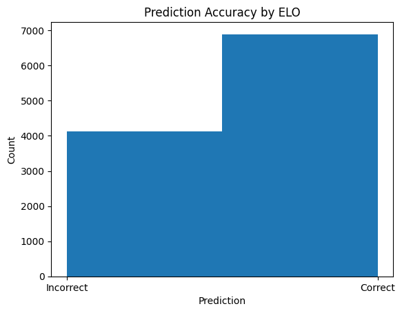

```
Elo Prediction Accuracy: 62.60%
```

```python
import pandas as pd
import matplotlib.pyplot as plt
import numpy as np
from datetime import timedelta

# compare the predicted winner from ELO to actual winner (home vs away score)
df_elo_predictions = df_elo_total_cleaned.copy()
df_elo_predictions = df_elo_predictions[['home_team', 'away_team', 'home_elo_pre', 'away_elo_pre', 'home_score', 'away_score']]
df_elo_predictions['predicted_winner'] = df_elo_predictions.apply(lambda row: row['home_team'] if row['home_elo_pre'] > row['away_elo_pre'] else row['away_team'], axis=1)
df_elo_predictions['actual_winner'] = df_elo_predictions.apply(lambda row: row['home_team'] if row['home_score'] > row['away_score'] else row['away_team'], axis=1)
df_elo_predictions['predicted_correct'] = df_elo_predictions['predicted_winner'] == df_elo_predictions['actual_winner']
df_elo_predictions['predicted_correct'].value_counts()

# graph the correct predictions based on elo

plt.hist(df_elo_predictions['predicted_correct'].astype(int), bins=2)
plt.xticks([0,1],['Incorrect', 'Correct'])
plt.xlabel('Prediction')
plt.ylabel('Count')
plt.title('Prediction Accuracy by ELO')
plt.show()

# show the percent of time that ELO predicts the outcome correctly

predicted_correct_percentage = df_elo_predictions['predicted_correct'].mean() * 100
print(f"Elo Prediction Accuracy: {predicted_correct_percentage:.2f}%")
```

According to the data, the team with the higher Elo score won roughly 63% of the time. This result was predictable, as the team with the higher Elo score was the "better" team.

Next, we examined the **impact of Elo Difference on the prediction accuracy of each game.** Analyzing Elo prediction accuracy across different Elo differences can reveal if larger Elo differences correlate with higher prediction accuracy, and help establish a signal for when Elo differences become important.

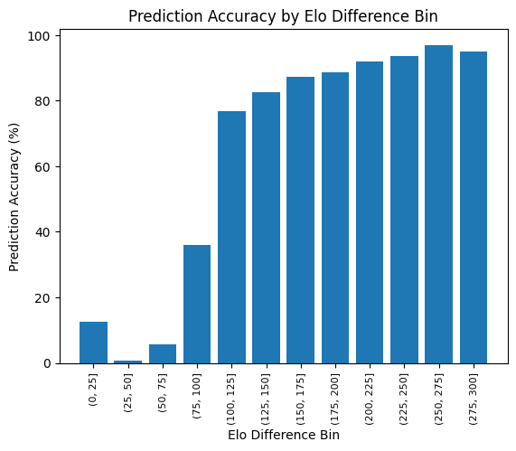

```
Prediction Accuracy by Elo Difference Bin (in %):
elo_diff_bin
(0, 25]       12.569832
(25, 50]       0.653595
(50, 75]       5.608755
(75, 100]     36.083916
(100, 125]    76.850606
(125, 150]    82.629108
(150, 175]    87.293729
(175, 200]    88.541667
(200, 225]    92.067308
(225, 250]    93.593315
(250, 275]    97.033898
(275, 300]    94.930876
Name: predicted_correct, dtype: float64
```

```python
df_elo_predictions['elo_diff'] = df_elo_total_cleaned['elo_diff']

# group by elo difference bins and calculate accuracy
df_elo_predictions['elo_diff_bin'] = pd.cut(df_elo_predictions['elo_diff'], bins=[0, 25, 50, 75, 100, 125, 150, 175, 200, 225, 250, 275, 300])
elo_diff_accuracy = df_elo_predictions.groupby('elo_diff_bin', observed=False)['predicted_correct'].mean() * 100

plt.bar(elo_diff_accuracy.index.astype(str), elo_diff_accuracy)
plt.xlabel('Elo Difference Bin')
plt.ylabel('Prediction Accuracy (%)')
plt.title('Prediction Accuracy by Elo Difference Bin')
plt.xticks(fontsize=8, rotation=90)
plt.show()

print("Prediction Accuracy by Elo Difference Bin (in %):")
print(elo_diff_accuracy)
```

Next, we **compared the historical spread favorite and ELO calculated spread** to give us a good idea on the alignment between historical market expectations and the elo based prediciton system. This analysis is important because it highlights trends in discrepencies, which can be used to help identify high value bets.

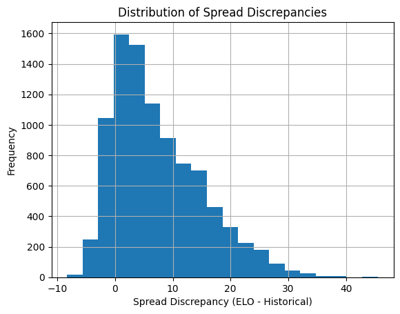

```python
# compare elo predicted spread and spread favorite
df_spread_comparison = df_total[['historical_spread', 'ELO_spread']].copy()

# find discrepency between historical and elo spreads
df_spread_comparison['spread_discrepancy'] = df_spread_comparison['ELO_spread'] - df_spread_comparison['historical_spread']
df_spread_comparison

df_spread_comparison['spread_discrepancy'].hist(bins=20)
plt.xlabel('Spread Discrepancy (ELO - Historical)')
plt.ylabel('Frequency')
plt.title('Distribution of Spread Discrepancies')
plt.show()
```

The graph is skewed to the right, with most values near 0 and decreasing as they move toward higher positive values. This suggests that in most cases, the Elo spread is close to the historical spread, which shows general agreement between the Elo model and the betting market. There is a long tail to the right, meaning there are instances where Elo sees more value in the underdog more than the market, which is indicated by high positive discrepancies. This chart can help indentify areas where ineffiencies between the elo and market can be exploited.

Finally, we investigated the **success rate of bets by spread discrepancy range**. We felt this was an important metic because it helps identify specific discrepency ranges that have higher sucess rates, which will help improve the profitability of the model.

```
Success Rate by Discrepancy Range:
discrepancy_bin
<-5         26.829268
-5 to -3    15.420561
-3 to 0     13.372093
0 to 3      31.731844
3 to 5      48.594742
>5          54.391278
Name: outcome, dtype: float64
```

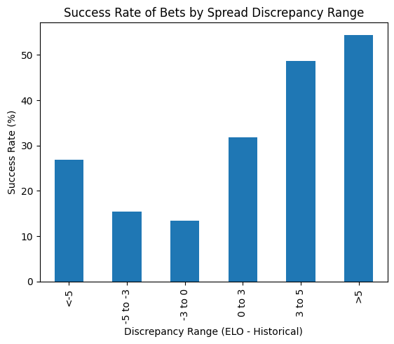

```python
df_spread_comparison['home_score'] = df_total['home_score']
df_spread_comparison['away_score'] = df_total['away_score']

# create function that calculates whether the favor/underdog covers
def calculate_winner(row):
    if row['historical_spread'] < 0: # home team is favorite
        if row['home_score'] - row['away_score'] > abs(row['historical_spread']):
            return 1 # favorite covers
        else:
            return 0 # favorite doesn't cover
    elif row['historical_spread'] > 0: # away team is favorite
        if row['away_score'] - row['home_score'] > abs(row['historical_spread']):
            return 1 # underdog covers
        else:
            return 0 # underdog doesn't cover
    else:
        return 2 # tie

df_spread_comparison['outcome'] = df_spread_comparison.apply(calculate_winner, axis=1)
df_spread_comparison

# create bins of different levels of spread discrepency
bins = [-float('inf'), -5, -3, 0, 3, 5, float('inf')]
labels = ['<-5', '-5 to -3', '-3 to 0', '0 to 3', '3 to 5', '>5']
df_spread_comparison['discrepancy_bin'] = pd.cut(df_spread_comparison['spread_discrepancy'], bins=bins, labels=labels)

# calculate success rate within each bin
success_rate_by_discrepancy = df_spread_comparison.groupby('discrepancy_bin', observed=False)['outcome'].mean() * 100
print("Success Rate by Discrepancy Range:")
print(success_rate_by_discrepancy)

success_rate_by_discrepancy.plot(kind='bar')
plt.xlabel('Discrepancy Range (ELO - Historical)')
plt.ylabel('Success Rate (%)')
plt.title('Success Rate of Bets by Spread Discrepancy Range')
plt.show()
```

These results suggest that Elo predicts a better result for the underdog, when the discrepency from the historical spread is greater than three. While it would need more testing and optimization, this could suggest that a good betting strategy would be to be on underdogs that fall into this range. This result aligns with the previous graph, as it predicted that the Elo system likes underdogs better than the market does.

### **Exploring the Impacts of Stadium Types and Weather Variables**

First, we **compared differences in total points between indoor & outdoor stadiums**. This analysis is useful because it gives more insight on the point potential for each game derived from factors that are unrelated to the game itself. This helps us establish whether external factors such as stadium type can be used as a predictor in our model.

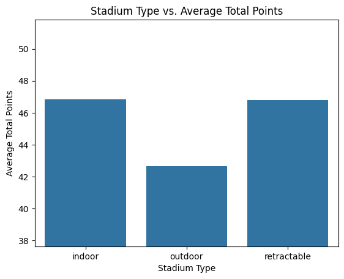

```python
import seaborn as sns
avg_points_by_stadium = df_total.groupby('stadium_type')['total_points'].mean().reset_index()

sns.barplot(x='stadium_type', y='total_points', data=avg_points_by_stadium)
plt.ylim(avg_points_by_stadium['total_points'].min() - 5, avg_points_by_stadium['total_points'].max() + 5)
plt.title('Stadium Type vs. Average Total Points')
plt.xlabel('Stadium Type')
plt.ylabel('Average Total Points')
plt.show()
```

This graph gives a very basic look at the affect indoor and outdoor stadiums have on average total points. It is clear games played in outdoor stadiums have a lower average total points, which is an important variable to consider when predicting if a spread will cover or an over/under line will succeed.

Next, we look at the **relationship between wind speed and average total points** to establish another key data point in determining if weather patterns have a clear and convincing impact on the results of the games point totals. If we can establish a correlation between certain weather patterns and game results, it would prove to be a very useful variable in determining the correct results for each game.

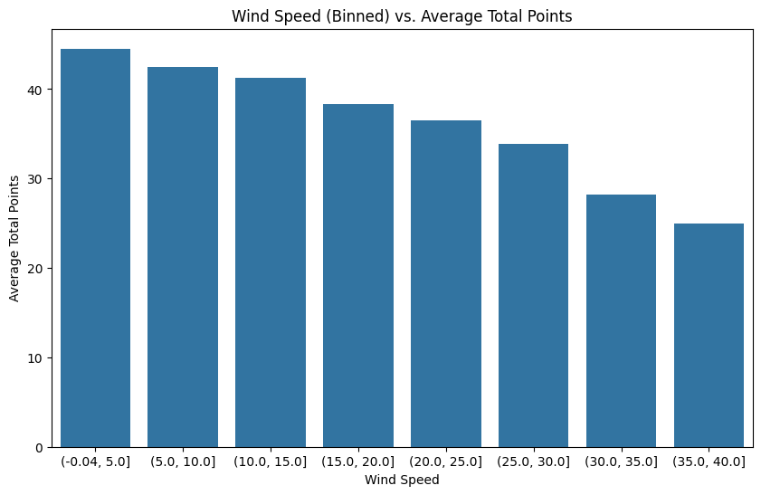

```python
df_total['wind_bin'] = pd.cut(df_total['weather_wind_mph'], bins=8)

avg_points_by_wind = df_total.groupby('wind_bin', observed=False)['total_points'].mean().reset_index()

plt.figure(figsize=(10, 6))
sns.barplot(x=avg_points_by_wind['wind_bin'].astype(str), y='total_points', data=avg_points_by_wind)
plt.title('Wind Speed (Binned) vs. Average Total Points')
plt.xlabel('Wind Speed')
plt.ylabel('Average Total Points')
plt.show()
```

This graph gives a very interesting look at the effect wind speed plays on average total points. It is the most useful weather metric in predicting game outcomes due to this clear correlation.

## **Hypothesis and Key Support**

1. We believe that based on the EDA our model will recommend more bets on games where the Elo-based prediction favors the underdogs more than the live betting markets do
2. Additionally, we believe that weather factors play a key role in determining outcomes of games, specifically when it deals with how many points are scored
3. Finally, we believe that we will be able to achieve a breakeven rate of at east ~52%, which will consider our model profitable

**In conclusion, we aim to build on the predictive success of the elo model using factors such as weather and stadium type to provide accurate betting predictions on whether the listed home team will cover the spread.**

## **Building Our Model**

To build our model, we need to first clean up our data to be usable for regression and classification. This includes making dummy variables, handling missing values, binning variables, and calculating some differential variables.

```python
from sklearn.preprocessing import StandardScaler
from sklearn.metrics import accuracy_score, classification_report, confusion_matrix, roc_auc_score

data = df_total.copy()

data['point_diff'] = data['home_score'] - data['away_score']
data['ATS_result'] = data['point_diff'] - data['historical_spread']
data['home_cover'] = (data['ATS_result'] > 0).astype(int)

data['weather_temperature'] = data['weather_temperature'].fillna(data['weather_temperature'].mean())
data['weather_wind_mph'] = data['weather_wind_mph'].fillna(data['weather_wind_mph'].mean())

data['temp_bin'] = pd.cut(data['weather_temperature'], bins=[-10, 0, 10, 20, 30, 40], labels=False)
data['wind_bin'] = pd.cut(data['weather_wind_mph'], bins=[0, 5, 10, 15, 20, 100], labels=False)
data['temp_bin'] = data['temp_bin'].fillna(data['temp_bin'].mode()[0])
data['wind_bin'] = data['wind_bin'].fillna(data['wind_bin'].mode()[0])

data['stadium_type'] = data['stadium_type'].fillna('Unknown')
data['stadium_open'] = data['stadium_open'].fillna(data['stadium_open'].mode()[0])

data = pd.get_dummies(data, columns=['stadium_type', 'stadium_surface'], drop_first=True)

data['elo_diff'] = data['home_elo_pre'] - data['away_elo_pre']
data['qb_elo_diff'] = data['home_qbelo_pre'] - data['away_qbelo_pre']
data['home_advantage'] = (~data['neutral']).astype(int)

week_mapping = {
    'Wildcard': 18,
    'Divisional': 19,
    'Conference': 20,
    'SuperBowl': 21
}

data['schedule_week'] = data['schedule_week'].replace(week_mapping)
data['schedule_week'] = pd.to_numeric(data['schedule_week'], errors='coerce')
data['schedule_week'] = data['schedule_week'].fillna(data['schedule_week'].median())

data['over_under_line'] = pd.to_numeric(data['over_under_line'].replace('pk', np.nan), errors='coerce')
data['over_under_line'] = data['over_under_line'].fillna(data['over_under_line'].mean())

data['home_favorite'] = (data['team_favorite_id'] == data['home_team']).astype(int)
data['away_favorite'] = (data['team_favorite_id'] == data['away_team']).astype(int)
data = data.drop(['team_favorite_id'], axis=1)

columns_to_drop = [
    'stadium', 'stadium_weather_type', 'home_team', 'away_team', 'home_qb', 'away_qb',
    'home_score', 'away_score', 'point_diff', 'ATS_result', 'home_elo_post', 'away_elo_post',
    'home_qbelo_post', 'away_qbelo_post', 'home_qb_value_post', 'away_qb_value_post',
    'home_qb_game_value', 'away_qb_game_value', 'importance', 'total_rating',
    'total_points', 'quality', 'elo_difference', 'ELO_spread', 'home_qb_adj', 'away_qb_adj'
] #drop these columns because they get calculated after the game
data = data.drop(columns=columns_to_drop, axis=1, errors='ignore')
```

Now that our data is ready to be used, lets split the data into training and test splits. We can split based off date which will be a better trainiing split than random because it will preserve the nature of past predicting the future in our model so we can accurately judge its predicting ability for the future.

```python
data = data.sort_values('date')
split_date = '2020-01-01'
train_data = data[data['date'] < split_date]
test_data = data[data['date'] >= split_date]

X_train = train_data.drop(['home_cover', 'date'], axis=1)
y_train = train_data['home_cover']
X_test = test_data.drop(['home_cover', 'date'], axis=1)
y_test = test_data['home_cover']

scaler = StandardScaler()
X_train = scaler.fit_transform(X_train)
X_test = scaler.transform(X_test)
```

First model type we want to test is Logistic Regression. Its a simple model but very effective. For performance of models we will look at the accuracy, classification report, the confusion matrix, and roc auc score. Accuracy will tell us the overall corectness, the classification report will give us the precision, recall, and f1-score which will tell us how the model performs for each class. The confusion matrix will show us the types of errors the model is making and the roc auc score will tell us how good the model is at distinguishing between the classes.

```python
from sklearn.linear_model import LogisticRegression

# 1000 iterations will give the model enough iterations to build a complex relationship and balanced class_weights will change class weights based on frequency
model = LogisticRegression(max_iter=1000, class_weight='balanced')
model.fit(X_train, y_train)

y_pred = model.predict(X_test)

print('Accuracy:', accuracy_score(y_test, y_pred))
print(classification_report(y_test, y_pred))
print("Confusion Matrix:\n", confusion_matrix(y_test, y_pred))
print('ROC AUC Score:', roc_auc_score(y_test, model.predict_proba(X_test)[:, 1]))
```

```
Accuracy: 0.6706827309236948
              precision    recall  f1-score   support

           0       0.51      0.78      0.62       170
           1       0.84      0.61      0.71       328

    accuracy                           0.67       498
   macro avg       0.68      0.70      0.66       498
weighted avg       0.73      0.67      0.68       498

Confusion Matrix:
 [[133  37]
 [127 201]]
ROC AUC Score: 0.7274928263988523
```

Next we will test RandomForestClassifier. This model type is strong at not overfitting and typically has high accuracy so it will be good to look at how it performs here.

```python
from sklearn.ensemble import RandomForestClassifier

# n_estimators at 100 is a good balance of efficiency and complexity
rf_model = RandomForestClassifier(n_estimators=100, class_weight='balanced')
rf_model.fit(X_train, y_train)

y_pred_rf = rf_model.predict(X_test)

print('Accuracy:', accuracy_score(y_test, y_pred_rf))
print(classification_report(y_test, y_pred_rf))
print("Confusion Matrix:\n", confusion_matrix(y_test, y_pred_rf))
print('ROC AUC Score:', roc_auc_score(y_test, rf_model.predict_proba(X_test)[:, 1]))
```

```
Accuracy: 0.6445783132530121
              precision    recall  f1-score   support

           0       0.46      0.26      0.33       170
           1       0.69      0.84      0.76       328

    accuracy                           0.64       498
   macro avg       0.58      0.55      0.54       498
weighted avg       0.61      0.64      0.61       498

Confusion Matrix:
 [[ 44 126]
 [ 51 277]]
ROC AUC Score: 0.6970946915351507
```

The final model we will look at is GradientBoostingClassifier. This model is strong at handling complex relationships and has high precision and effectiveness in predictive accuracy.

```python
from sklearn.ensemble import GradientBoostingClassifier

#learning rate and depth at 0.1 & 3 prevent overfitting but also allow for complex relationships
gb_model = GradientBoostingClassifier(n_estimators=100, learning_rate=0.1, max_depth=3)
gb_model.fit(X_train, y_train)

y_pred_gb = gb_model.predict(X_test)

print('Accuracy:', accuracy_score(y_test, y_pred_gb))
print(classification_report(y_test, y_pred_gb))
print("Confusion Matrix:\n", confusion_matrix(y_test, y_pred_gb))
print('ROC AUC Score:', roc_auc_score(y_test, gb_model.predict_proba(X_test)[:, 1]))
```

```
Accuracy: 0.642570281124498
              precision    recall  f1-score   support

           0       0.47      0.38      0.42       170
           1       0.71      0.78      0.74       328

    accuracy                           0.64       498
   macro avg       0.59      0.58      0.58       498
weighted avg       0.63      0.64      0.63       498

Confusion Matrix:
 [[ 64 106]
 [ 72 256]]
ROC AUC Score: 0.713459469153515
```

After looking at all 3 models performances, Logistic Regression is the most effective model across most metrics, performing the best in overall accuracy and ROC AUC, making it the best choice as a model.

## **Profitability Analysis and Next Steps**

In order to show how a potential better might fare using this model, we conducted a simple profitability analysis. Assuming a bettor makes 100 bets, at 100 dollars each on the home team to cover the spread (-110 odds), they would net $2,791 profit with a ~28% return on their investment. This is based on our Logistic Regression model's accuracy of 67%.

Our next steps would be to engage in web-scraping to find all real-time data, and continue an analysis to see if the betting model would work as well on new data!